# R3.01 - Environnement économique: Economie financière

Chapitre 1: Le financement et les acteurs

Thomas Delcey

thomas.delcey@ube.fr

Université de Bourgogne Europe

# Chapitre 0 : Introduction

### Objectif du cours

**Définition : l’environnement économique**

L’environnement économique désigne l’ensemble des facteurs économiques qui influencent le fonctionnement et la prise de décision des acteurs économiques (croissance, inflation, taux d’intérêt, chômage, inégalités, etc.).

- Comprendre le rôle central de la finance dans l’environnement économique :
  1. Les mécanismes de base et acteurs de la finance.
  2. Qui crée la monnaie ?
  3. Est-ce qu’il y a une bulle de l’IA ?
  4. À quoi sert la banque centrale européenne ?

### Plan du cours

- **Chapitre 1 :** Le financement et les acteurs (CM).
  - Un TD sur les marchés financiers.
- **Chapitre 2 :** La monnaie (CM).
  - Un TD sur la création monétaire.
- **Chapitre 3 :** Bulles et crises financières (CM).
  - Un TD sur la crise de 2007-2008.
- **Chapitre 4 :** La banque centrale (CM).
  - Un TD sur la théorie et les politiques monétaires.

### Évaluation

- 1 devoir surveillé en TD, la semaine du 13 octobre
- Questions sur les TD ET les CM
- 4 ou 5 questions ouvertes argumentées et rédigées. Pas de QCM.

### Un mot sur l’IA

[figure not shown]

- **Dette cognitive**
- **Amplificateur**

[video not shown]

### Ressources

- Support de cours et sujets des TD distribués ;
- Écrivez-moi / venez me voir si vous cherchez des ressources complémentaires pour approfondir un sujet ;

# Chapitre 1 : Le financement des acteurs

### Le problème du chapitre

Une entreprise qui veut investir, un ménage qui veut acheter un logement, un État qui construit une école : tous ont besoin d’un argent qu’ils n’ont pas encore.

**Le problème du chapitre**

D’où vient cet argent, et pourquoi coûte-t-il quelque chose ?

### La finance dans l’imaginaire collectif

[figure not shown]

[figure not shown]

[figure not shown]

### La finance dans la réalité

**Définition : la finance**

La finance peut se définir comme l’ensemble des activités qui visent à fournir l’argent nécessaire pour produire ou consommer un bien ou un service.

- **Ménages** : globalement en capacité de financement
- **Organisations (entreprises)** : globalement en besoin de financement
- **État** : globalement en besoin de financement
- **Reste du monde** : en capacité ou en besoin selon le solde des échanges avec l’étranger

### Les différents types de financement d’une organisation

**Définition : le capital**

- En économie, le capital est l’ensemble des biens et services d’une entreprise nécessaire à la production.
- En finance, on parle d’une somme d’investissement passé pour générer un profit futur.
1. L’autofinancement ou financement interne
2. Le financement externe  
   2.1. Le financement indirect 2.2. Le financement direct

### Capital social et emprunt

**Définition : L’augmentation du capital social de l’entreprise**

Le capital social représente les ressources apportées par les associées de l’organisation. Une augmentation de capital social permet à l’organisation de lever des fonds en émettant de nouvelles parts sociales, ce qui augmente les ressources propres de l’entreprise.

**Définition : le financement par emprunt**

Le crédit, ou l’emprunt, correspond au transfert d’argent sous forme de prêt de la part d’un créancier (un prêteur) vers un débiteur (un emprunteur) contre un intérêt.

### Vocabulaires

- Selon la discipline et la forme juridique de l’organisation, il existe une diversité de termes pour désigner ces même deux modalités de financement
  - **Capital social** : actions, capital propre, parts sociales, etc.
  - **Emprunt** : crédit, dette, obligations, etc.

**Marchés des capitaux**

- Pour les grandes entreprises, ces modalités de financement sont négociés sur des marchés spécialisés:
  - Marché des actions (titre d’actions)
  - Marché des obligations (titre d’obligations)
- Il existe un marché primaire (du neuf) et secondaire (de l’occasion)

### Le profit

**Définition : le profit**

- Le profit est la rémunération perçue par celui qui apporte du capital à une organisation.
  - Les dividendes ou la revente d’actions rémunèrent l’actionnaire.
  - Les intérêts négociés d’un emprunt rémunèrent le prêteur.

**Les dividendes n’enrichissent pas l’actionnaire**

Un versement de dividendes transforme du profit illiquide en profit liquide.

**Pourquoi payer un profit ?**

**Dans une économie capitaliste, le profit — dividende ou intérêt — rémunère le risque et le temps.**

### Comment estimer le profit d’un investissement ?

- L’intérêt simple se calcule uniquement sur la base de la somme investie initiale:

$$V_t = V_0 \cdot (1 + r \cdot t)$$

- L’intérêt composé se calcule sur la base de la somme investie initiale et les intérêts générés sur les périodes précédentes:

$$V_t = V_0 \cdot (1 + r)^t$$

Avec $V_t$ la valeur de la somme investie à la période $t$, $t \in [0, 1, ..., t]$ la période écoulée (en année, mois, semaines) et $r$ le rendement de l’investissement.

### Illustration : intérêt simple et composé

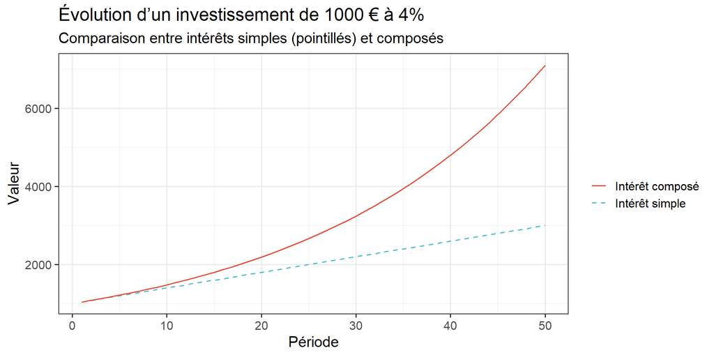

### Illustration : comparaison de taux

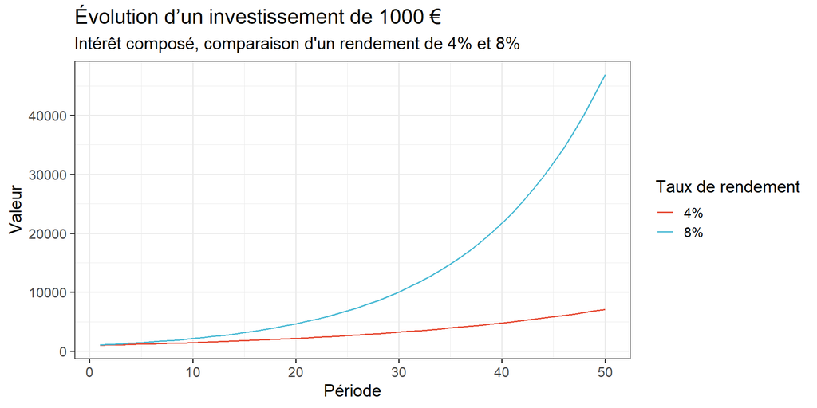

### Capitalisation et actualisation

- La **capitalisation** permet de calculer la valeur **future** d’un investissement aujourd’hui.

$$V_t = V_0 \cdot (1 + r)^t$$

- L’**actualisation** permet de calculer la valeur **actuelle** d’un investissement futur.

$$V_0 = \frac{V_t}{(1 + r)^t}$$

### Synthèse du chapitre

- **Trois modalités** : autofinancement, financement indirect (la banque prête l’épargne collectée), financement direct (émission de titres). *Direct ne veut pas dire sans intermédiaire.*
- **Deux leviers externes, plusieurs vocabulaires** : capital social (actions, parts sociales) et emprunt (crédit, dette, obligations). Seul le marché primaire apporte de l’argent à l’organisation.
- **Le profit — dividende ou intérêt — rémunère le risque et le temps.** C’est ce que mesurent la capitalisation, vers l’avant, et l’actualisation, vers l’arrière.

### Wooclap de fin de chapitre